# Detectando Atividades Fraudulentas

Data Science Academy

03 de Agosto, 2018

# 1. Definição do Problema

Os sites de comércio eletrônico lidam com um alto risco de usuários realizarem atividades fraudulentas. A Aprendizagem de Máquina realmente se destaca na identificação de atividades fraudulentas e no combate a esta ação criminosa. O objetivo deste projeto é construir um modelo de aprendizado de máquina que seja capaz de prever a probabilidade de que a primeira transação de um novo usuário seja fraudulenta. Os dados utilizados são fictícios, mas representam o acesso de usuários a um site de comércio eletrônico. Embora não contemplado aqui, recomendamos que você explore os dados antes de construir o modelo. Utilize tudo que você aprendeu no curso.

1. Carrega os pacotes

```r
library(dplyr)
library(randomForest)
library(ROCR)
```

2. Carrega os datasets

```r
data = read.csv("Fraud_Data.csv")
ip_addresses = read.csv("IpAddress_to_Country.csv")
```

# 2. Processa os Dados

Verifica a existência de duplicatas

```r
nrow(data) == length(unique(data$user_id))
```

```
## [1] TRUE
```

Adiciona país ao conjunto de dados original com base em endereços IP

```r
data_country = rep(NA, nrow(data))
for (i in 1: nrow(data)){
tmp = as.character(ip_addresses [data$ip_address[i] >= ip_addresses$lower_bound_ip_address & data$ip_address[i] <= ip_addresses$upper_bound_ip_address,"country"])
if (length(tmp) == 1) {data_country[i] = tmp}
}
data$country = data_country
data[, "signup_time"] = as.POSIXct(data[, "signup_time"], tz="GMT")
data[, "purchase_time"] = as.POSIXct(data[, "purchase_time"], tz="GMT")
summary(as.factor(data$country))
```

```
##                   United States                           China
##                           58049                           12038
##                           Japan                  United Kingdom
##                            7306                            4490
##               Korea Republic of                         Germany
##                            4162                            3646
##                          France                          Canada
##                            3161                            2975
##                          Brazil                           Italy
##                            2961                            1944
##                       Australia                     Netherlands
##                            1844                            1680
##              Russian Federation                           India
##                            1616                            1310
## Taiwan; Republic of China (ROC)                          Mexico
##                            1237                            1121
##                          Sweden                           Spain
##                            1090                            1027
##                    South Africa                     Switzerland
##                             838                             785
##                          Poland                       Argentina
##                             729                             661
##                       Indonesia                          Norway
##                             649                             609
##                        Colombia                          Turkey
##                             602                             568
##                        Viet Nam                         Romania
##                             550                             525
##                         Denmark                       Hong Kong
##                             490                             471
##                         Finland                         Austria
##                             460                             435
##                         Ukraine                           Chile
##                             429                             417
##                         Belgium      Iran (ISLAMIC Republic Of)
##                             409                             389
##                           Egypt                  Czech Republic
##                             359                             349
##                        Thailand                     New Zealand
##                             291                             278
```

[output cut: 45 more lines]

```
##                              31                              30
##                     Puerto Rico                          Jordan
##                              30                              28
##                         Lebanon                     El Salvador
##                              28                              25
##                           Qatar                           Sudan
##                              25                              25
##                          Angola                       Macedonia
##                              24                              24
##            Syrian Arab Republic                      Azerbaijan
##                              24                              23
##                         Namibia                           Malta
##                              23                              22
##                         (Other)                            NA's
##                             550                           21966
```

# 3 Feature Engineering

Algumas variáveis óbvias que podem ser criadas aqui podem ser:

1. Diferença de horário entre o horário de inscrição e o tempo de compra
2. Se o ID do dispositivo é exclusivo ou certos usuários compartilhem o mesmo dispositivo (muitos ID de usuário diferentes usando o mesmo dispositivo podem ser um indicador de contas falsas).
3. Muitos usuários diferentes que tenham o mesmo endereço IP podem ser um indicador de contas falsas.
4. Semana usual do ano e dia da semana a partir de variáveis de tempo.

Calcula a diferença de horário entre compra e inscrição

```r
data$purchase_signup_diff = as.numeric(difftime(as.POSIXct(data$purchase_time, tz="GMT"), as.POSIXct(data$signup_time, tz="GMT"), unit="secs"))
```

Verifica para cada identificação de cada dispositivo id / endereço IP quantos usuários diferentes estão usando o mesmo endereço

```r
data <- data %>%
  group_by(device_id) %>%
  mutate (device_id_count = n())

data <- data %>%
  group_by(ip_address) %>%
  mutate (ip_address_count = n())
```

Dia da semana e semana do ano

```r
data$signup_time_wd = format(data$signup_time, "%A")
data$purchase_time_wd = format(data$purchase_time, "%A" )
data$signup_time_wy = as.numeric(format(data$signup_time, "%U"))
data$purchase_time_wy = as.numeric(format(data$purchase_time, "%U" ))
```

Descarta variáveis indesejadas do conjunto de dados

```r
data_rf = data[, -c(1:3, 5)]
```

Mantém os 50 melhores países e tudo mais é “outro”

```r
data_rf$country[is.na(data_rf$country)]="Not_found"
data_rf$country = ifelse(data_rf$country %in% names(sort(table(data_rf$country),decreasing = TRUE))[51:length(unique(data_rf$country))],"Other", as.character(data_rf$country))
```

Variáveis necessárias do processo

```r
# Transforma a classe em fator
data_rf$class = as.factor(data_rf$class)

# Todas as variáveis do tipo character se tornam fator
data_rf[sapply(data_rf, is.character)] <- lapply(data_rf[sapply(data_rf, is.character)], as.factor)
```

# 4. Separa dados de treino e de teste

O modelo será ajustado usando 2/3 de dados como treino e 1/3 restante dos dados como conjunto de dados de teste.

```r
train_sample = sample(nrow(data_rf), size = nrow(data)*0.66)
train_data = data_rf[train_sample,]
test_data = data_rf[-train_sample,]
```

Para o problema dado, escolhemos o método RandomForest para as previsões. As florestas aleatórias geralmente exigem muito pouco tempo para otimizar (seus parâmetros padrões são frequentemente próximos dos melhores) e são robustos com variáveis abertas, variáveis irrelevantes, contínuas e discretas. Além disso, eles fornecem parcelas de dependência parcial e importância de variável para obter informações sobre como a informação é derivada das variáveis. O método da floresta aleatória é conhecido por ser flexível e tem variância relativamente menor do que uma árvore individual.

```r
rf = randomForest(y=train_data$class, x = train_data[, -7],ytest = test_data$class,
                  xtest = test_data[, -7],ntree = 50, mtry = 3, keep.forest = TRUE)
print(rf)
```

```
##
## Call:
##  randomForest(x = train_data[, -7], y = train_data$class, xtest = test_data[,      -7], ytest = test_data$class, ntree = 50, mtry = 3, keep.forest = TRUE)
##                Type of random forest: classification
##                      Number of trees: 50
## No. of variables tried at each split: 3
##
##         OOB estimate of  error rate: 4.49%
## Confusion matrix:
##       0    1 class.error
## 0 90201  241 0.002664691
## 1  4239 5052 0.456247982
##                 Test set error rate: 4.39%
## Confusion matrix:
##       0    1 class.error
## 0 46471   48 0.001031836
## 1  2205 2655 0.453703704
```

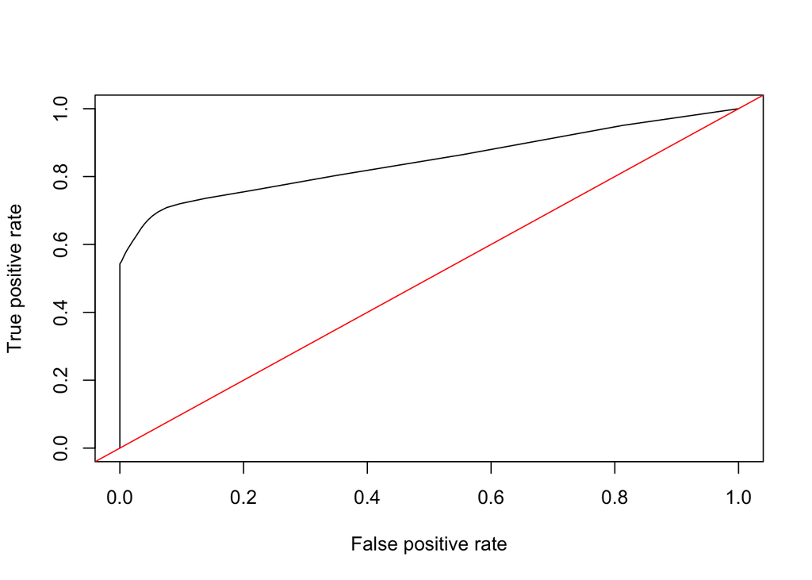

```
## integer(0)
```

```r
# Vamos combinar em um modelo de conjunto de dados previsões e valores reais.
# A primeira coluna são as classes reais em nosso conjunto de teste e a segunda são as pontuações previstas
rf_results = data.frame (true_values = test_data$class,predictions = rf$test$votes[,2])
pred = prediction (rf_results$predictions, rf_results$true_values)

# Plot ROC mostrando verdadeiro positivo versus falso positivo
perf = performance (pred, measure = 'tpr', x.measure = "fpr")
plot(perf) + abline(a=0, b=1, col = 'red')
```

# 5. Conclusão

O modelo produz a probabilidade de um novo usuário cometer fraude e uma probabilidade de corte adequada deve ser selecionada para classificar um usuário específico como fraude. Por exemplo, o método padrão de floresta aleatória usa 0,5 como ponto de corte. Se a prioridade é minimizar os falsos positivos, um ponto de corte de aproximadamente 0.5 e taxa de falso positivo próximo de zero devem ser escolhidos . No entanto, se nos preocupamos em maximizar o verdadeiro positivo, teremos que diminuir o corte. Desta forma, classificaremos mais eventos como “1”: alguns serão verdadeiros (então, o verdadeiro positivo aumenta) e muitos, infelizmente, serão falsos (então, falso positivo também vai subir).